# mixed_uptake_analysis.Rmd

Ross Cunning

July 27, 2016

# Data import and calculation of cell numbers in polyps

### Import standard curve data

```r
std <- read.csv("stdcurves.csv")
std$CT <- as.numeric(as.character(std$CT))
std$Plate <- as.factor(std$Plate)
std <- std[which(std$Quantity<=64000), ]  # Ignore data from 128,000 cells
```

### Import polyp data

```r
polyp <- read.csv("polyps_clean.csv") ##samples that we re-run multiple times were causing a problem downstream but now have cleaned up raw data file to remove poor quality data resulting in just one set of data for each sample-target
polyp <- polyp[, c("Plate", "Sample", "Target", "CT")]
polyp$CT <- as.numeric(as.character(polyp$CT))
polyp$Plate <- as.numeric(as.character(polyp$Plate))
target <- polyp$Target
polyp$Target <- as.numeric(as.factor(polyp$Target))
# Aggregate technical replicates -- samples where only one replicate amplified will return as NA
polyp <- aggregate(polyp, by=list(Sample=polyp$Sample, Target=polyp$Target, Plate=polyp$Plate), FUN=mean)
polyp$Target <- levels(target)[polyp$Target]
polyp <- polyp[,c(1,2,3,7)]
```

### Visualize standard curves on each plate

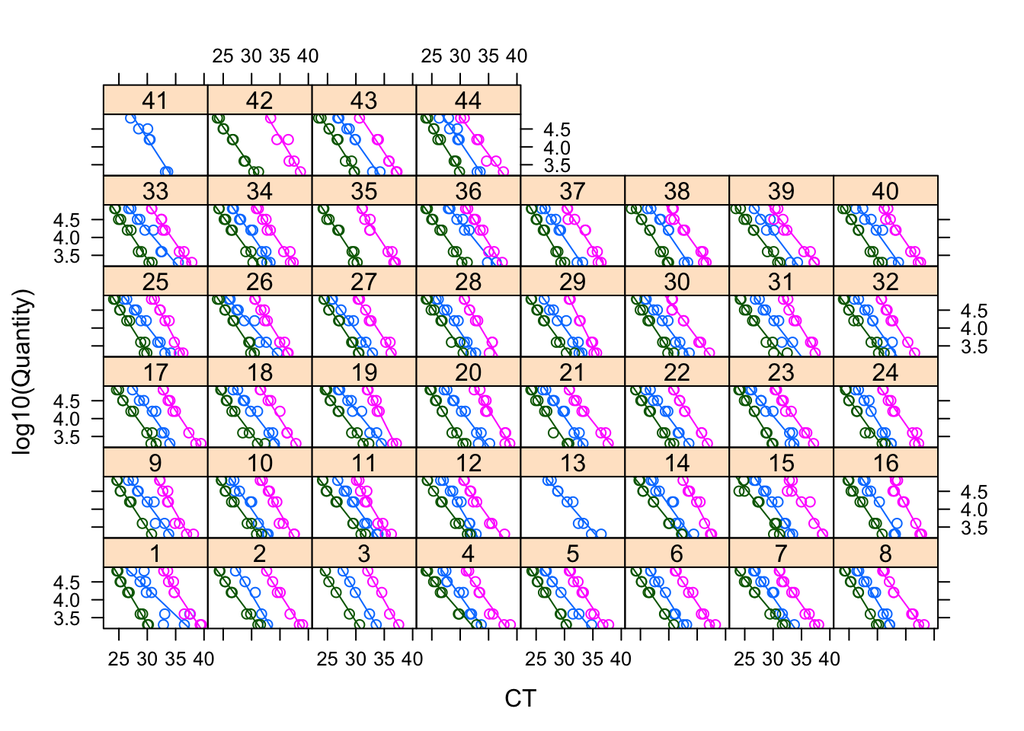

```r
xyplot(log10(Quantity) ~ CT | Plate, groups=Target, type=c("p", "r"), data=std)
```

### Fit mixed model to standard curve data

```r
curves <- lmerTest::lmer(log10(Quantity) ~ CT * Target + (Target|Plate) + (CT|Plate), data=std)
anova(curves)  # Interaction is significant --> slopes are different
```

```
## Analysis of Variance Table of type III  with  Satterthwaite
## approximation for degrees of freedom
##            Sum Sq Mean Sq NumDF   DenDF F.value    Pr(>F)
## CT        220.205 220.205     1   61.96 13566.5 < 2.2e-16 ***
## Target      4.443   2.221     2 1069.98   136.9 < 2.2e-16 ***
## CT:Target   0.576   0.288     2 1049.67    17.7 2.639e-08 ***
## ---
## Signif. codes:  0 '***' 0.001 '**' 0.01 '*' 0.05 '.' 0.1 ' ' 1
```

### Calculate quantities for polyp samples using model

```r
#predict(curves, newdata=polyp)
# error: plate 1 not present in standard curve data ---????
# remove plate 1 samples for now...##fixed data sheet to include Plate 1 SEM 1 Aug 2016
##polyp <- droplevels(polyp[which(polyp$Plate!="1"), ]) ##fixed by SEM 1 Aug 2016
polyp$Quantity2 <- 10^predict(curves, newdata=polyp)
#polyp$Quantity2 <- 10^predict(curves, newdata=polyp, re.form=NA)
```

### Import sample data and merge with qPCR data

```r
sam <- read.csv("treatments.csv")  # sample data is called "treatments.csv"
sam <- sam[, c("Sample", "Sym_ID", "Env", "Time", "Rep")]
df <- merge(sam, polyp, by = "Sample")
# Identify samples that were successful mixed infections
nclades <- aggregate(df$Quantity2, by=list(Sample=df$Sample), FUN=function(x) length(is.na(x)[is.na(x)==F]))
rownames(nclades) <- nclades$Sample
df$mixed <- ifelse(nclades[as.character(df$Sample), "x"] == 2 , TRUE, FALSE)  ##Changed to "==2" because some contamination caused a few samples to have 3 clades
df$mixed[which(nchar(as.character(df$Sym_ID))==1)] <- NA

# What symbionts did each sample actually have??
actual <- with(df[which(!is.na(df$Quantity2)), ],
               aggregate(data.frame(actual=Target), by=list(Sample=Sample),
                         FUN=function(x) paste0(x[order(x)], collapse="")))
df <- merge(df, actual, by="Sample")
# If they actually had what they were offered, then success = T, otherwise success = F
df$success <- ifelse(df$actual==as.character(df$Sym_ID), TRUE, FALSE)
```

### Create function to test deviation from deWit expectations and plot results

This function is subsequently used to run analyses for different pairs of symbionts. The function subsets the relevant data for the selected symbionts and time point, **excludes polyps that were offered two symbionts but only took up one**, and then fits a mixed model **(with plate included as a random factor)** to the log-transformed cell quantity data. For each focal symbiont, the quantity of cells in the mixed infection is compared to the quantity of cells in the single infection divided by two. All single and mixed observations are maintained in the model, **allowing the variance of the single infection data to be maintained** in the statistical test, instead of reducing this variance to zero by using a single value as the “expected” value (e.g., half of the mean value from single infections, as was done previously). The function then plots the results in the same format as before, and returns the results of the statistical tests comparing actual values in mixed infections to expected values.

```r
deWit <- function(s1, s2, time, data) {
  # Create a subset of the data for symbionts s1 and s2 at the selected time point (time)
  df <- subset(data,
               Time==time &
               Sym_ID %in% c(s1, paste0(c(s1, s2)[order(c(s1, s2))], collapse=""), s2) &
               Target %in% c(s1, s2) &
               #(mixed==T | is.na(mixed)))  # excludes polyps that were offered two symbionts but only took up one
               success==T) # only includes polyps that actually had what they were offered

  df <- droplevels(df)  # drop empty factor levels
  # Fit a mixed model to compare abundance of symbiont1 in mixed infection to expected value
  # of deWit model (i.e., half of the values from symbiont1 single infections)
  levs <- levels(df$Sym_ID)[grep(s1, levels(df$Sym_ID))]
  s1mod <- with(subset(df, Target==s1 & Sym_ID %in% levs), {
    # Divide quantities of focal symbiont in single infections by 2 to get deWit expectations
    Quantity2[which(Sym_ID==s1)] <- Quantity2[which(Sym_ID==s1)] / 2
    # Fit mixed model
    lmer(log10(Quantity2) ~ Sym_ID * Env + (1|Plate))
  })
  # Compute lsmeans and contrasts
  s1lsm <- lsmeans(s1mod, specs="Sym_ID", by="Env", contr="trt.vs.ctrl", ref=match(s1, levs))

  # Fit a mixed model to compare abundance of symbiont2 in mixed infection to expected value
  # of deWit model (i.e., half of the values from symbiont2 single infections)
  levs <- levels(df$Sym_ID)[grep(s2, levels(df$Sym_ID))]
  s2mod <- with(subset(df, Target==s2 & Sym_ID %in% levs), {
    # Divide quantities of focal symbiont in single infections by 2 to get deWit expectations
    Quantity2[which(Sym_ID==s2)] <- Quantity2[which(Sym_ID==s2)] / 2
    # Fit mixed model with plate as random factor
    lmer(log10(Quantity2) ~ Sym_ID * Env + (1|Plate))
  })
  # Compute lsmeans and contrasts
  s2lsm <- lsmeans(s2mod, specs="Sym_ID", by="Env", contr="trt.vs.ctrl", ref=match(s2, levs))

  # Compute full model for lsmeans
  fullmod <- lmer(log10(Quantity2) ~ Target * Sym_ID * Env + (Target|Plate), data=df)
  fulllsm <- lsmeans(fullmod, specs=c("Sym_ID", "Env", "Target"))

  # Create a two-panel figure plotting lsmeans
  par(mfrow=c(1,2))
    # Subset "dark" data and plot
  dark <- subset(summary(fulllsm), Env=="Dark")
  dark$lsmean[is.na(dark$lsmean)] <- 0
  dark$Q <- 10^dark$lsmean
  dark$`Q+se` <- 10^(dark$lsmean + dark$SE)
  dark$`Q-se` <- 10^(dark$lsmean - dark$SE)
  max <- max(dark$`Q+se`, na.rm=T)
  plot(Q ~ as.numeric(Sym_ID), data=dark, xaxt="n", xlab="", main="Dark", ylim=c(0, max),
       col=c("red", "blue", "purple")[match(Target, c("A","B","D"))])
  with(dark, arrows(as.numeric(Sym_ID), `Q+se`, as.numeric(Sym_ID), `Q-se`, angle=90, code=3, length=0.05,
                    col=c("red", "blue", "purple")[match(Target, c("A","B","D"))]))
  axis(side=1, at=unique(as.numeric(dark$Sym_ID)), labels=levels(dark$Sym_ID)[unique(as.numeric(dark$Sym_ID))])
  for (s in levels(factor(dark$Target))) {
    lines(Q ~ as.numeric(Sym_ID), lty=2, col=c("red", "blue", "purple")[match(Target, c("A","B","D"))],
          data=subset(dark, Target==s & nchar(as.character(Sym_ID))==1))
    lines(Q ~ as.numeric(Sym_ID), lty=1, col=c("red", "blue", "purple")[match(Target, c("A","B","D"))],
          data=subset(dark, Target==s))
  }
  # Subset "light" data and plot
  light <- subset(summary(fulllsm), Env=="Light")
  light$lsmean[is.na(light$lsmean)] <- 0
  light$Q <- 10^light$lsmean
  light$`Q+se` <- 10^(light$lsmean + light$SE)
  light$`Q-se` <- 10^(light$lsmean - light$SE)
  max <- max(light$`Q+se`, na.rm=T)
  plot(Q ~ as.numeric(Sym_ID), data=light, xaxt="n", xlab="", main="Light", ylim=c(0, max),
       col=c("red", "blue", "purple")[match(Target, c("A","B","D"))])
  with(light, arrows(as.numeric(Sym_ID), `Q+se`, as.numeric(Sym_ID), `Q-se`, angle=90, code=3, length=0.05,
                     col=c("red", "blue", "purple")[match(Target, c("A","B","D"))]))
  axis(side=1, at=unique(as.numeric(light$Sym_ID)), labels=levels(light$Sym_ID)[unique(as.numeric(light$Sym_ID))])
  for (s in levels(factor(light$Target))) {
    lines(Q ~ as.numeric(Sym_ID), lty=2, col=c("red", "blue", "purple")[match(Target, c("A","B","D"))],
          data=subset(light, Target==s & nchar(as.character(Sym_ID))==1))
    lines(Q ~ as.numeric(Sym_ID), lty=1, col=c("red", "blue", "purple")[match(Target, c("A","B","D"))],
          data=subset(light, Target==s))
  }


  # Return contrasts and summary stats
  return(list(s1lsm=s1lsm, s2lsm=s2lsm, fulllsm=fulllsm))
}
```

## deWit analysis for B and D @ time 1

```r
t1DB <- deWit(s1="D", s2="B", time=1, data=df)
```

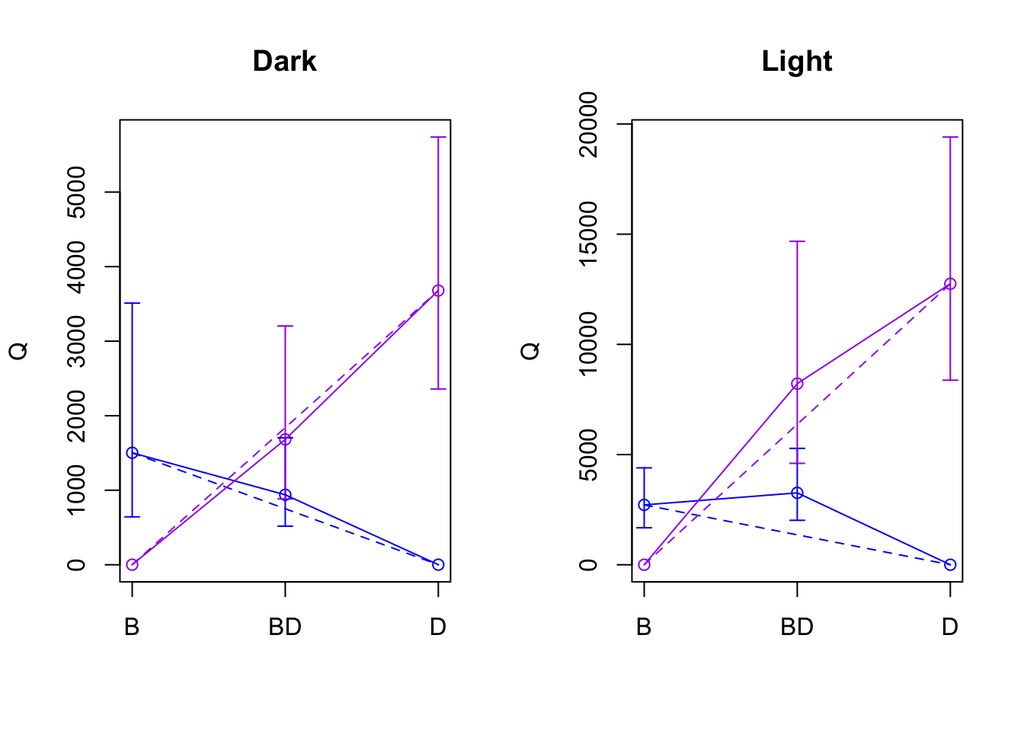

#### Test whether D is different from deWit expectations when mixed with B

In the contrast computed below, “BD - D” indicates the difference between the actual amount of D when mixed with B, and the amount of D expected by the deWit model. Thus, a negative value for the contrast “estimate” indicates that the actual value is less than the expected value, and a positive value indicate the actual value is greater than expected. These estimates are only significant when p < alpha.

```r
t1DB$s1lsm$contrasts
```

```
## Env = Dark:
##  contrast    estimate        SE    df t.ratio p.value
##  BD - D   -0.02543212 0.2918797 19.79  -0.087  0.9314
##
## Env = Light:
##  contrast    estimate        SE    df t.ratio p.value
##  BD - D    0.14184639 0.2605391 21.40   0.544  0.5918
```

#### Test whether B is different from deWit expectations when mixed with D

```r
t1DB$s2lsm$contrasts
```

```
## Env = Dark:
##  contrast  estimate        SE    df t.ratio p.value
##  BD - B   0.1033915 0.3874532 10.77   0.267  0.7946
##
## Env = Light:
##  contrast  estimate        SE    df t.ratio p.value
##  BD - B   0.3307381 0.2290981  7.05   1.444  0.1918
```

## deWit analysis for A and D @ time 1

```r
t1AD <- deWit(s1="A", s2="D", time=1, data=df)
```

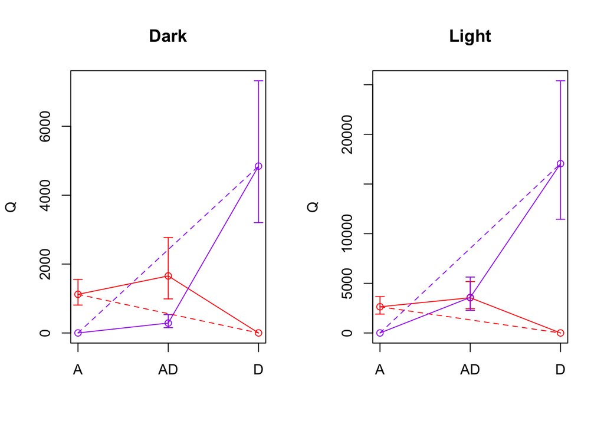

#### Test whether A is different from deWit expectations when mixed with D

```r
t1AD$s1lsm$contrasts
```

```
## Env = Dark:
##  contrast  estimate        SE    df t.ratio p.value
##  AD - A   0.4779053 0.2151039 21.15   2.222  0.0373
##
## Env = Light:
##  contrast  estimate        SE    df t.ratio p.value
##  AD - A   0.4745836 0.1604757 22.90   2.957  0.0071
```

#### Test whether D is different from deWit expectations when mixed with A

```r
t1AD$s2lsm$contrasts  # A greater than expected in light and dark
```

```
## Env = Dark:
##  contrast   estimate        SE    df t.ratio p.value
##  AD - D   -0.8279043 0.2707551 19.10  -3.058  0.0064
##
## Env = Light:
##  contrast   estimate        SE    df t.ratio p.value
##  AD - D   -0.3286461 0.1866761 20.18  -1.761  0.0935
```

```r
                                          # D less than expected in dark, almost significantly less than expected in light
```

## deWit analysis for A and B @ time 1

```r
t1AB <- deWit(s1="A", s2="B", time=1, data=df)
```

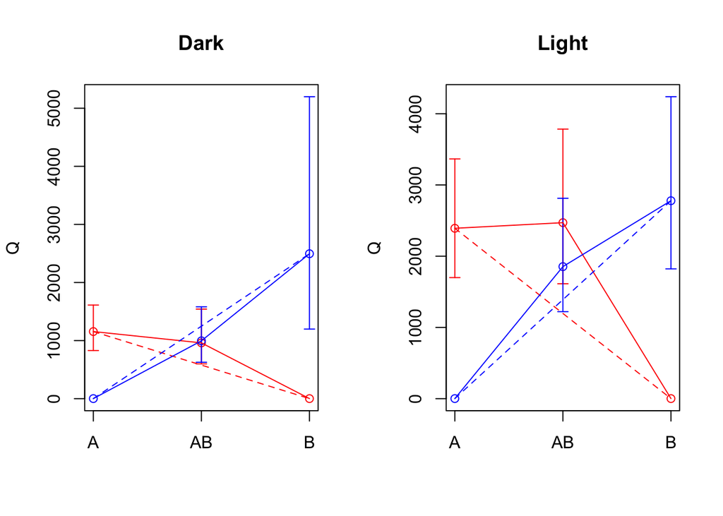

#### Test whether A is different from deWit expectations when mixed with B

```r
t1AB$s1lsm$contrasts
```

```
## Env = Dark:
##  contrast  estimate        SE    df t.ratio p.value
##  AB - A   0.2600979 0.2313481 26.82   1.124  0.2709
##
## Env = Light:
##  contrast  estimate        SE    df t.ratio p.value
##  AB - A   0.3407739 0.2074454 24.05   1.643  0.1135
```

#### Test whether B is different from deWit expectations when mixed with A

```r
t1AB$s2lsm$contrasts
```

```
## Env = Dark:
##  contrast    estimate        SE    df t.ratio p.value
##  AB - B   -0.05673016 0.3685185  7.90  -0.154  0.8815
##
## Env = Light:
##  contrast    estimate        SE    df t.ratio p.value
##  AB - B    0.06115876 0.2629295 14.66   0.233  0.8193
```

## deWit analysis for B and D @ time 2

```r
t2DB <- deWit(s1="D", s2="B", time=2, data=df)
```

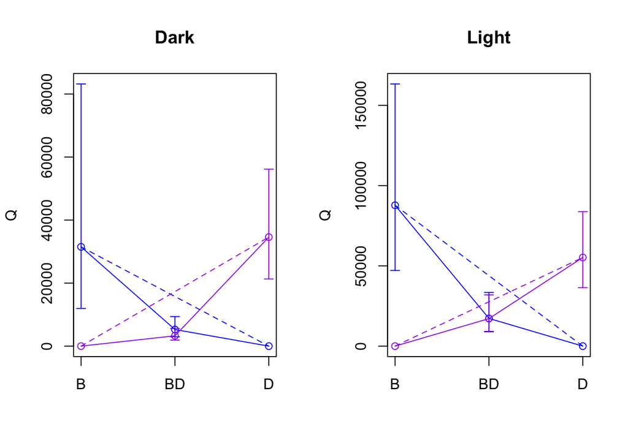

#### Test whether D is different from deWit expectations when mixed with B

```r
t2DB$s1lsm$contrasts
```

```
## Env = Dark:
##  contrast   estimate        SE    df t.ratio p.value
##  BD - D   -0.8921260 0.2983566 23.31  -2.990  0.0065
##
## Env = Light:
##  contrast   estimate        SE    df t.ratio p.value
##  BD - D   -0.2747522 0.3024108 20.65  -0.909  0.3741
```

#### Test whether B is different from deWit expectations when mixed with D

```r
t2DB$s2lsm$contrasts
```

```
## Env = Dark:
##  contrast   estimate        SE   df t.ratio p.value
##  BD - B   -0.5768833 0.2203274 3.55  -2.618  0.0666
##
## Env = Light:
##  contrast   estimate        SE   df t.ratio p.value
##  BD - B   -0.1303933 0.3669159 8.31  -0.355  0.7312
```

## deWit analysis for A and D @ time 2

```r
t2AD <- deWit(s1="A", s2="D", time=2, data=df)
```

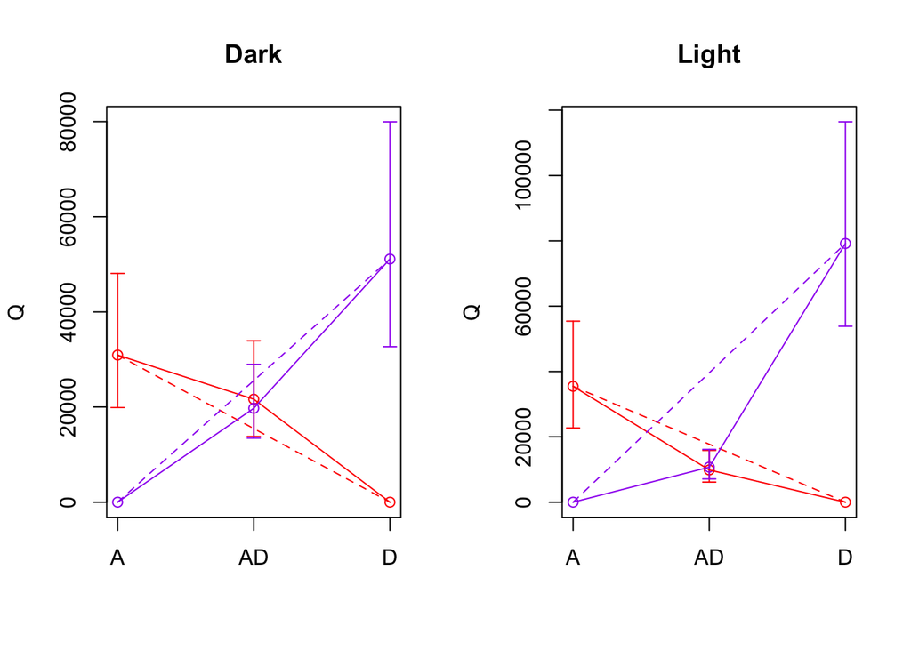

#### Test whether A is different from deWit expectations when mixed with D

```r
t2AD$s1lsm$contrasts
```

```
## Env = Dark:
##  contrast    estimate        SE    df t.ratio p.value
##  AD - A    0.09412212 0.2019991 36.31   0.466  0.6440
##
## Env = Light:
##  contrast    estimate        SE    df t.ratio p.value
##  AD - A   -0.27503568 0.2065704 34.25  -1.331  0.1918
```

#### Test whether D is different from deWit expectations when mixed with A

```r
t2AD$s2lsm$contrasts
```

```
## Env = Dark:
##  contrast   estimate        SE    df t.ratio p.value
##  AD - D   -0.1594638 0.2234790 29.66  -0.714  0.4811
##
## Env = Light:
##  contrast   estimate        SE    df t.ratio p.value
##  AD - D   -0.6063686 0.2147339 31.38  -2.824  0.0082
```

## deWit analysis for A and B @ time 2

```r
t2AB <- deWit(s1="A", s2="B", time=2, data=df)
```

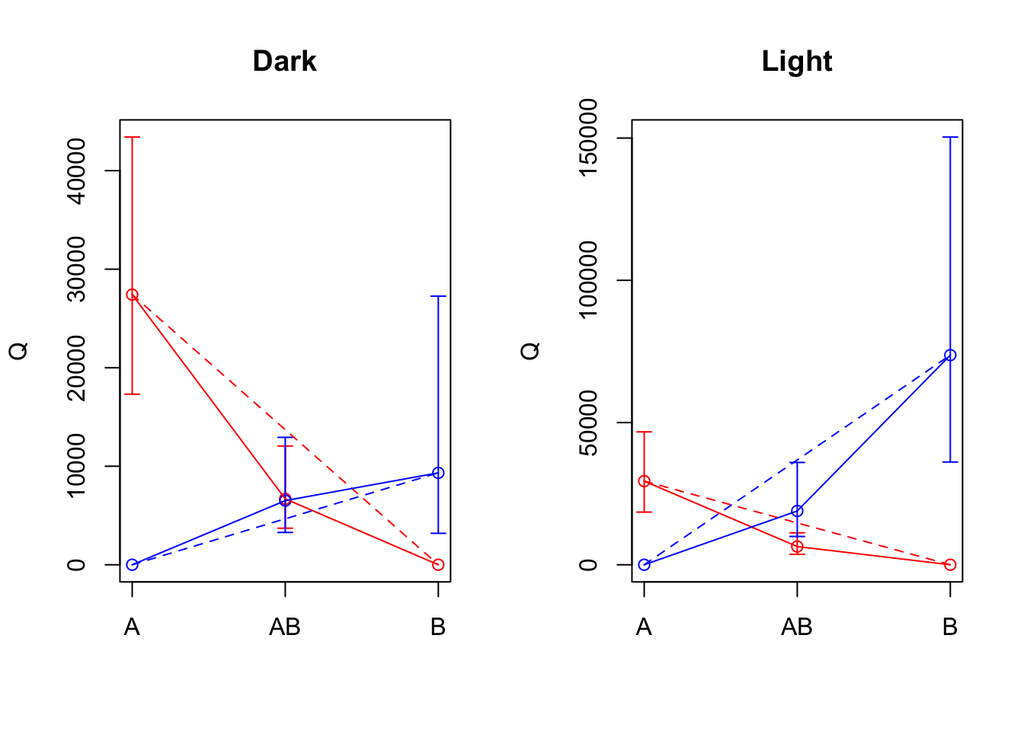

#### Test whether A is different from deWit expectations when mixed with B

```r
t2AB$s1lsm$contrasts
```

```
## Env = Dark:
##  contrast   estimate        SE    df t.ratio p.value
##  AB - A   -0.3135215 0.2581394 27.24  -1.215  0.2350
##
## Env = Light:
##  contrast   estimate        SE    df t.ratio p.value
##  AB - A   -0.3682034 0.2479852 27.43  -1.485  0.1490
```

#### Test whether B is different from deWit expectations when mixed with A

```r
t2AB$s2lsm$contrasts
```

```
## Env = Dark:
##  contrast   estimate        SE   df t.ratio p.value
##  AB - B    0.2934943 0.2007425 5.49   1.462  0.1985
##
## Env = Light:
##  contrast   estimate        SE   df t.ratio p.value
##  AB - B   -0.4433761 0.1489665 5.72  -2.976  0.0262
```